# 4_Session4_TSeriesGraphs_Asynchronous_Solutions

1/31/2022

# Students data:

# Packages

You need to at least install and load these packages (you may need to install more during code execution, so please pay attention to any warning messages indicating if this is required).

```r
library(fpp3)
library(GGally)
```

# Exercise 1

The `aus_retail` dataset is loaded along with the fpp3 package. It contains a variety of series that that might be filtered using their specific series ID. We will be working the the following Series ID: A3349767W.

The Turnover is specified in $Million AUD. This can be checked running `?aus_retail` in the console.

**Filter that series ID and use the functions `autoplot()`, `gg_season()`, `gg_subseries()`, `gg_lag()` and `ACF() %>% autoplot()` to explore the time series and provide an interpretation of each of the graphs.** Focus on he following questions (you will be graded based on your answer to these questions):

- Can you spot any seasonality, cyclicity and trend?
- What do you learn about the series?
- What can you say about the seasonal patterns?
- Can you identify any unusual years?

NOTE: really long answers are not necessarily better than condensed answers that go to the point.

The following code filters the series you should work with.

```r
retail_series <- aus_retail %>%
  filter(`Series ID` == "A3349767W")

head(retail_series)
```

```
## # A tsibble: 6 x 5 [1M]
## # Key:       State, Industry [1]
##   State              Industry                      `Series ID`    Month Turnover
##   <chr>              <chr>                         <chr>          <mth>    <dbl>
## 1 Northern Territory Clothing, footwear and perso~ A3349767W   1988 Apr      2.3
## 2 Northern Territory Clothing, footwear and perso~ A3349767W   1988 May      2.9
## 3 Northern Territory Clothing, footwear and perso~ A3349767W   1988 Jun      2.6
## 4 Northern Territory Clothing, footwear and perso~ A3349767W   1988 Jul      2.8
## 5 Northern Territory Clothing, footwear and perso~ A3349767W   1988 Aug      2.9
## 6 Northern Territory Clothing, footwear and perso~ A3349767W   1988 Sep      3
```

## Timeplot:

Let us first generate the timeplot:

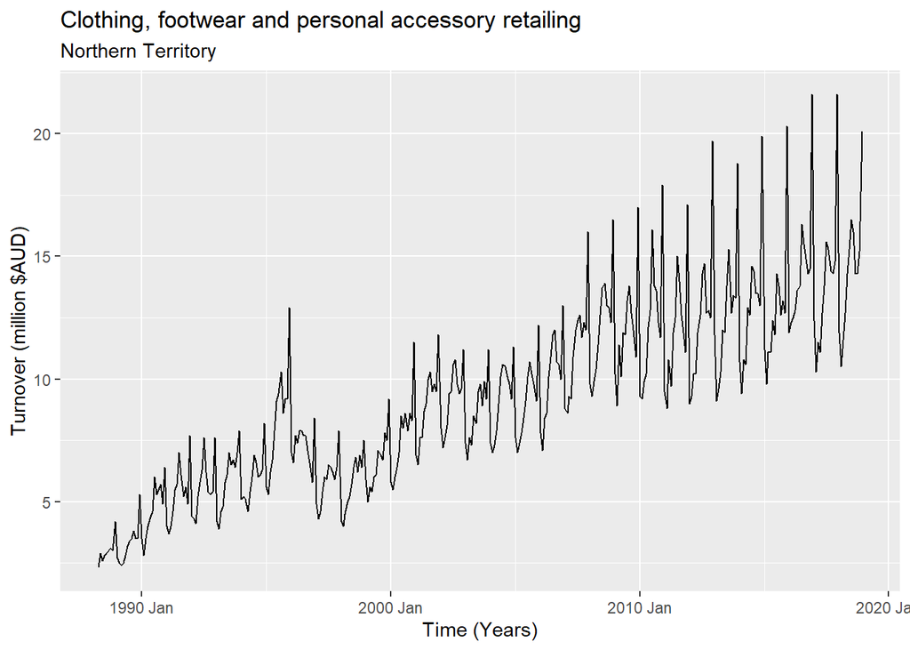

```r
retail_series %>%
  autoplot(Turnover) +
  labs(y = "Turnover (million $AUD)", x = "Time (Years)",
       title = retail_series$Industry[1],
       subtitle = retail_series$State[1])
```

This series clearly shows a non-linear upward trend and a strong seasonal pattern. These seasonal patterns seem proportional to the level of the trend over this time period.

In case it is unclear whether the seasonality follows a yearly pattern, we could further divide the x-graph:

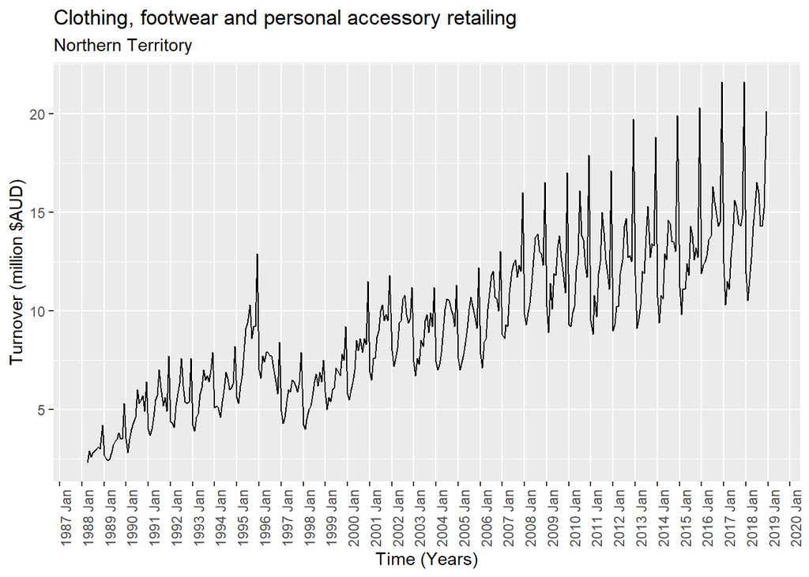

```r
retail_series %>%

  autoplot(Turnover) +

  labs(y = "Turnover (million $AUD)", x = "Time (Years)",
       title = retail_series$Industry[1],
       subtitle = retail_series$State[1]) +

  scale_x_yearmonth(date_breaks = "1 year",
                    date_minor_breaks = "1 year") +

  # Flip x-labels by 90 degrees
  theme(axis.text.x = element_text(angle = 90))
```

Just for your knowledge, please note that *autoplot* function is nothing else but a wrapper for other ggplot functions:

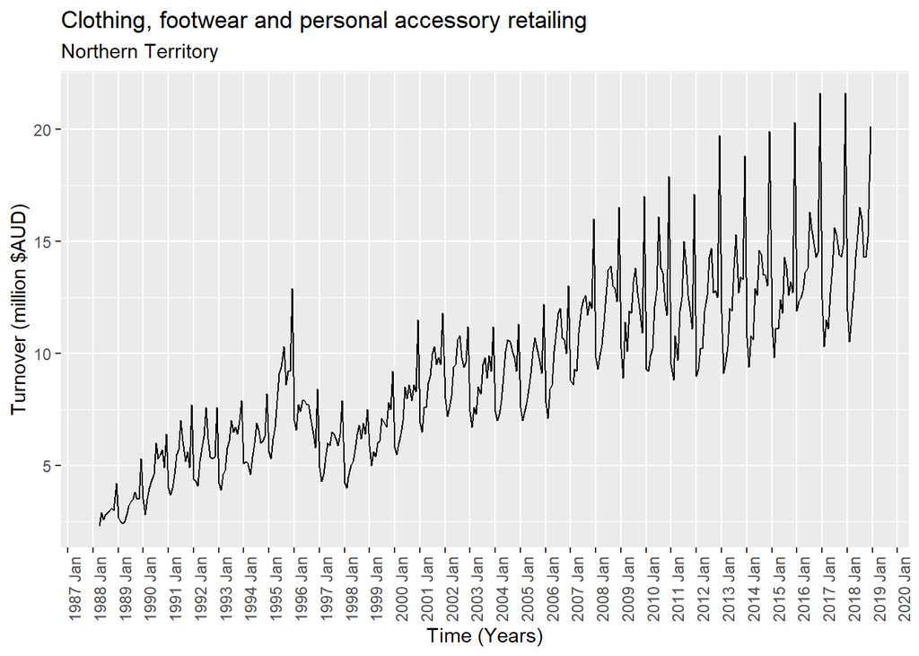

```r
retail_series %>%
  ggplot(aes(x = Month, y = Turnover)) +

  geom_line() +

  labs(y = "Turnover (million $AUD)", x = "Time (Years)",
     title = retail_series$Industry[1],
     subtitle = retail_series$State[1]) +

  scale_x_yearmonth(date_breaks = "1 year",
                    date_minor_breaks = "1 year") +

  # Flip x-labels by 90 degrees
  theme(axis.text.x = element_text(angle = 90))
```

**QUESTION**: environment control in R.

## season plot

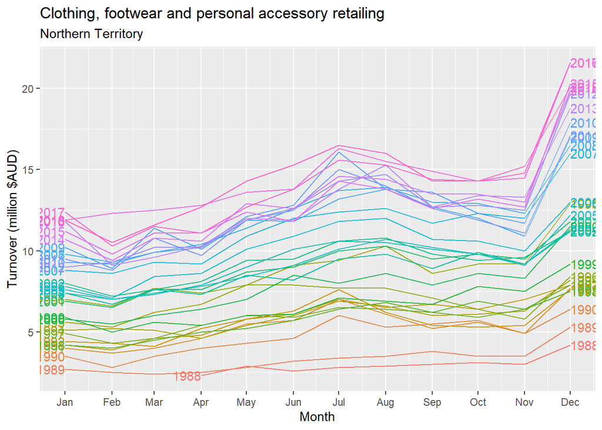

```r
retail_series %>%
  gg_season(Turnover, labels = "both") +
  labs(y = "Turnover (million $AUD)",
       title = retail_series$Industry[1],
       subtitle = retail_series$State[1])
```

## Seasonal subseries plots

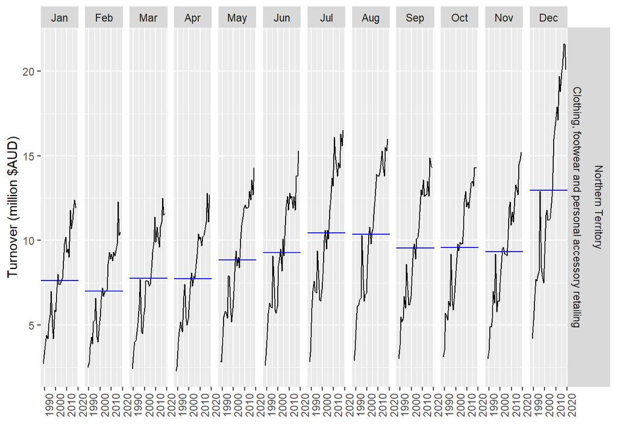

```r
retail_series %>%
  gg_subseries(Turnover) +
  labs(y = "Turnover (million $AUD)", x="")
```

- Growth trend in all months.
- largest increase in December.
- July and August also present an above average growth.

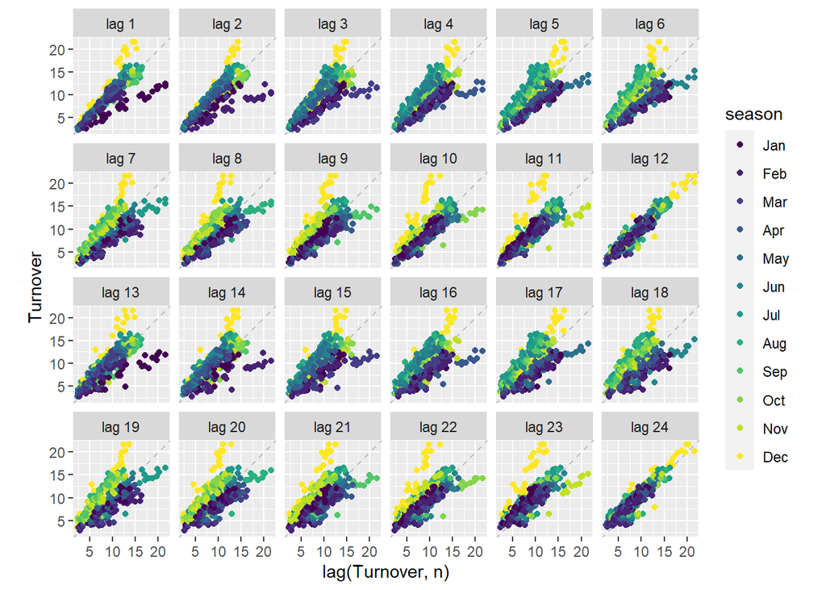

```r
retail_series %>%

  # Creates the lagplot
  gg_lag(Turnover, lags=1:24, geom='point') +

  # Adjusts the nubmer of columns
  # See source code for .lag:
  # https://rdrr.io/github/tidyverts/tsibblestats/src/R/graphics.R
  facet_wrap(~ .lag, ncol=6)
```

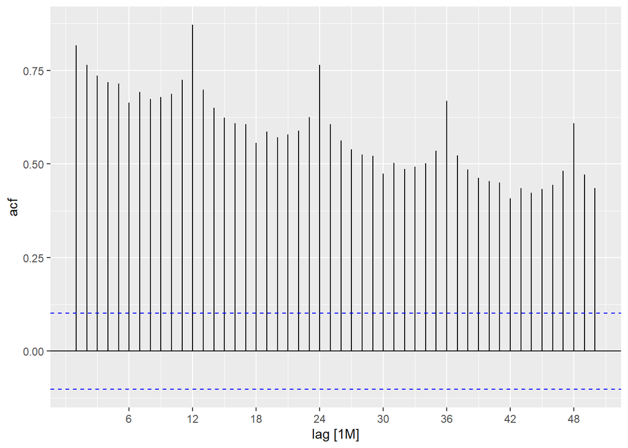

```r
retail_series %>%
  ACF(Turnover, lag_max = 50) %>%
  autoplot()
```

Both the lagplot and the correlogram show a much greater correlation with lags 12, 24… This clearly indicates that there is a seasonal pattern of 12 months in this series.

# Exercise 2

**Use the functions `autoplot()`, `gg_season()`, `gg_subseries()`, `gg_lag()` and `ACF() %>% autoplot()` to explore the time series provided in every section below and provide an interpretation of each of the graphs.** Focus on the following questions (you will be graded based on your answer to these questions):

- Can you spot any seasonality, cyclicity and trend?
- What do you learn about the series?
- What can you say about the seasonal patterns?
- Can you identify any unusual years?

NOTE: really long answers are not necessarily better than condensed answers that go to the point.

## 2.1 Australian Bricks Production

```r
# Code to filter the dataset
# Remember you can obtain information about the dataset using ?aus_production()
brick_pr <- aus_production %>%
  select(Quarter, Bricks)

head(brick_pr)
```

```
## # A tsibble: 6 x 2 [1Q]
##   Quarter Bricks
##     <qtr>  <dbl>
## 1 1956 Q1    189
## 2 1956 Q2    204
## 3 1956 Q3    208
## 4 1956 Q4    197
## 5 1957 Q1    187
## 6 1957 Q2    214
```

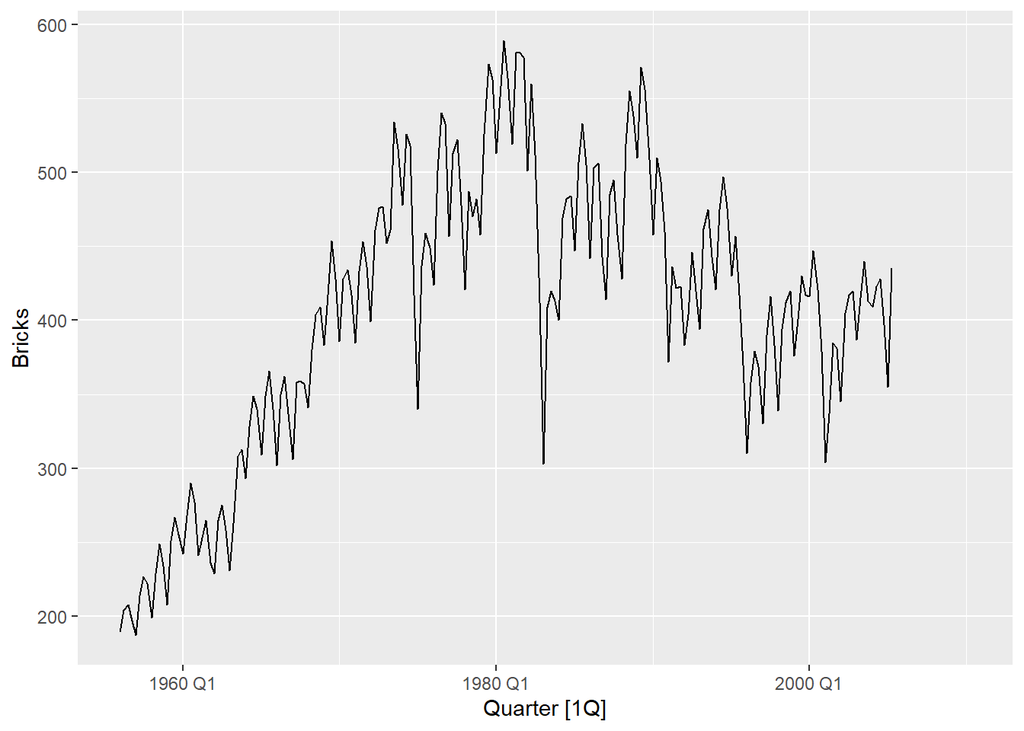

```r
aus_production %>% autoplot(Bricks)
```

The series seems to exhibit a seasonal pattern. To make sure this pattern is yearly we could further adjust the grid of the time plot:

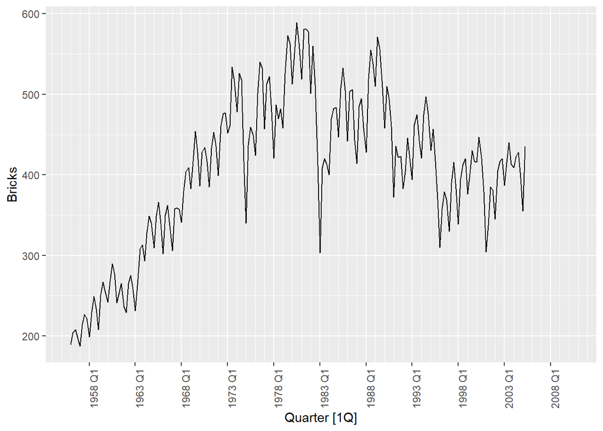

```r
aus_production %>%
  autoplot(Bricks) +

  # We pick scale_x_yearquarter() because the time-index
  # consists in quarterly data
  scale_x_yearquarter(date_breaks = "5 years",
                      date_minor_breaks = "1 year") +

  # Flip x-labels by 90 degrees
  theme(axis.text.x = element_text(angle = 90))
```

This further adjustment of the grid confirms the yearly seasonality we suspected.

The series also exhibits: * An upward trend until 1980. * A subsequent decline in the production of bricks. * Some sharp drops in some quarters

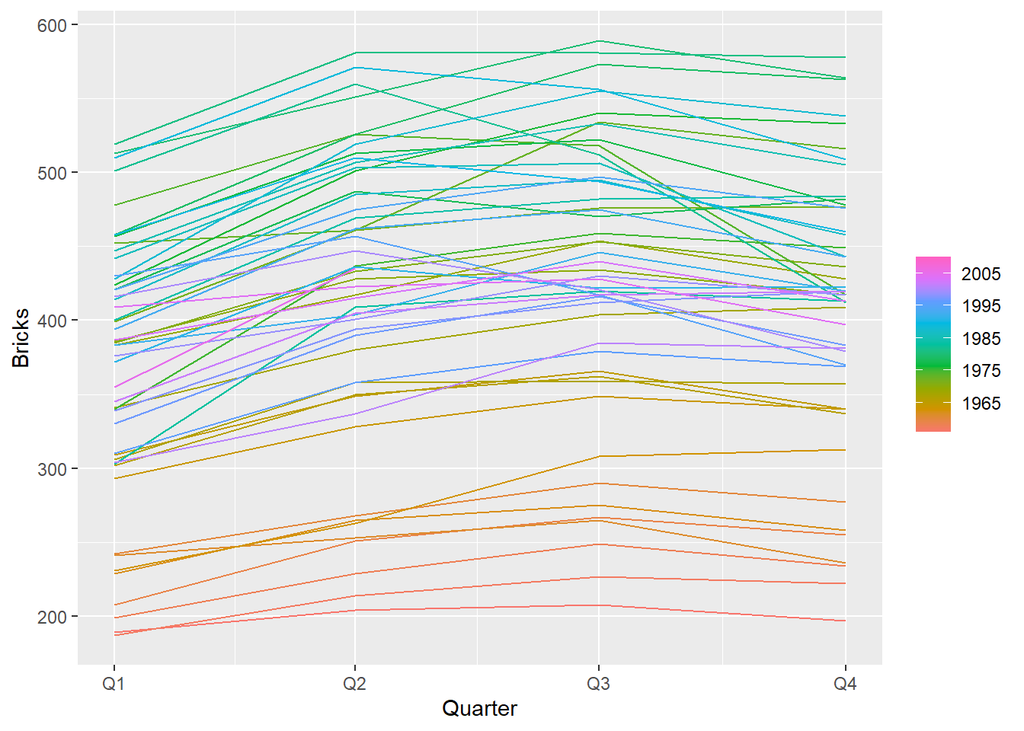

```r
aus_production %>%
  gg_season(Bricks)
```

The first quarter tends to be the worst in terms of bricks production, and the second or third quarter tend to be the yearly picks.

There is an initial upwards trend and from 1980 onwards this tendency reverses, as we saw in the timeplot.

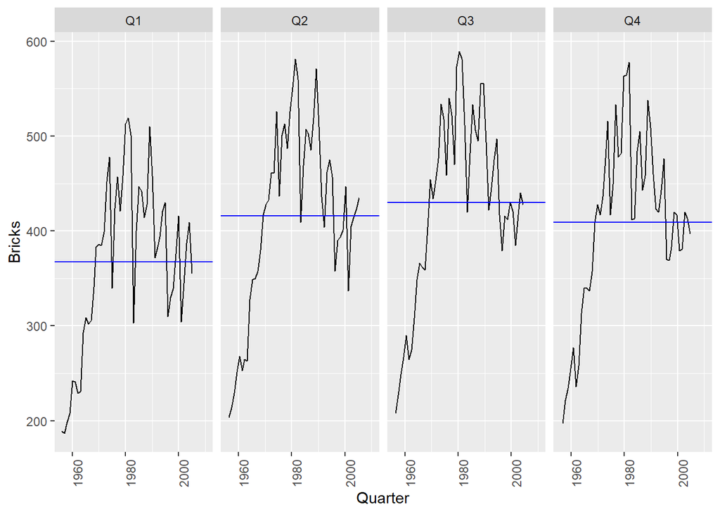

```r
aus_production %>%
  gg_subseries(Bricks)
```

One noteworthy aspect is that the decrease in the last 25 years has been less marked on Q1.

On the other hand the plot confirms that, any given year, Q2 or Q3 contain the peaks of the series.

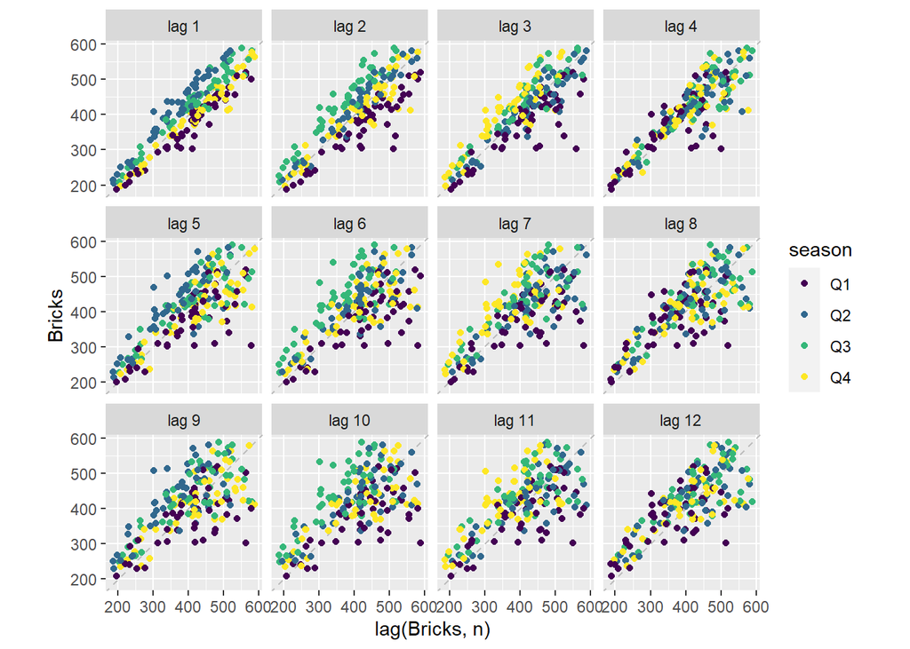

```r
aus_production %>%
  gg_lag(Bricks, geom='point', lags=1:12)
```

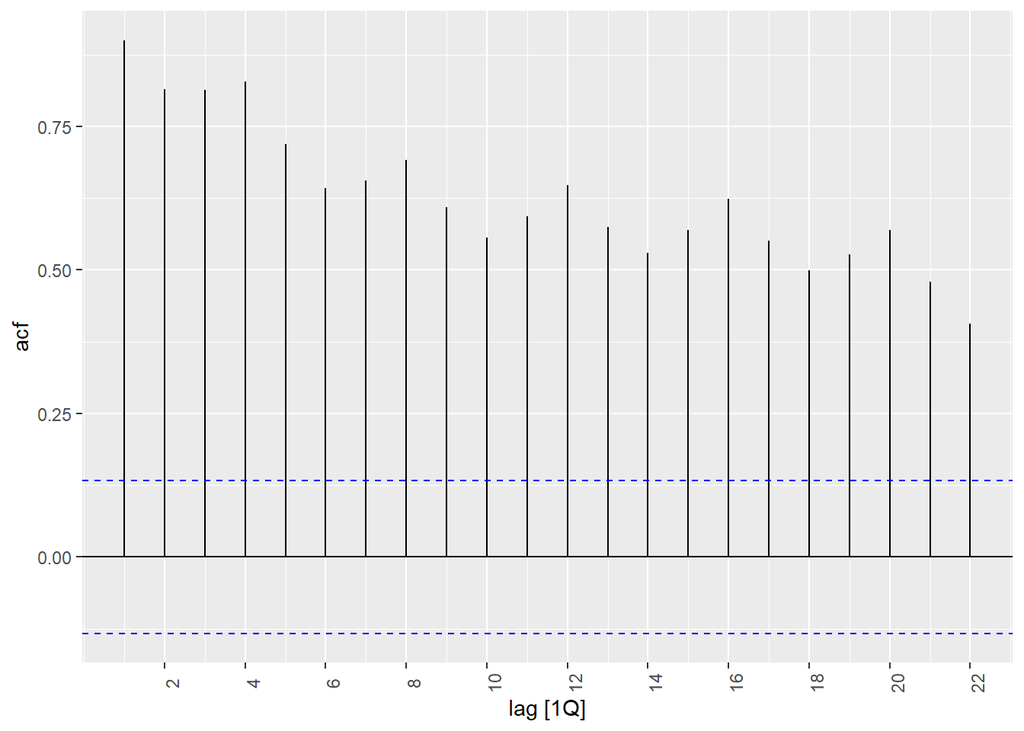

```r
aus_production %>%
  ACF(Bricks) %>% autoplot() +

  # Flip x-labels by 90 degrees
  theme(axis.text.x = element_text(angle = 90))
```

The spikes in the correlogram on the multiples of 4 indicate that this series exhibits yearly seasonality. This is much clearer on the correlogram than in the lagplots, which might not be so informative in this particular case due to the effect of the trend.

On the other hand the trend is also reflected on the correlogram in the continuous slowly-decreasing pattern. This indicates that nearby observations are also near in value, that is, there is a trend. Note that this remains true even though the trend reverses at one point.

## 2.2 Snowshoe Hare pelts traded

The pelt dataset (loaded with fpp3) contains trading records for Snowshoe Hare and Canadian Lynx furs from 1845 to 1935. This data contains trade records for all areas of the company. Use `?pelt` to obtain further information.

Focus on the series corresponding to the Snowshow Hare

```r
Hare_tr <- pelt %>%
  select(Year, Hare)

# Combines both heads and tails vertically
bind_rows(head(Hare_tr), tail(Hare_tr))
```

```
## # A tsibble: 12 x 2 [1Y]
##     Year  Hare
##    <dbl> <dbl>
##  1  1845 19580
##  2  1846 19600
##  3  1847 19610
##  4  1848 11990
##  5  1849 28040
##  6  1850 58000
##  7  1930  4230
##  8  1931 19520
##  9  1932 82110
## 10  1933 89760
## 11  1934 81660
## 12  1935 15760
```

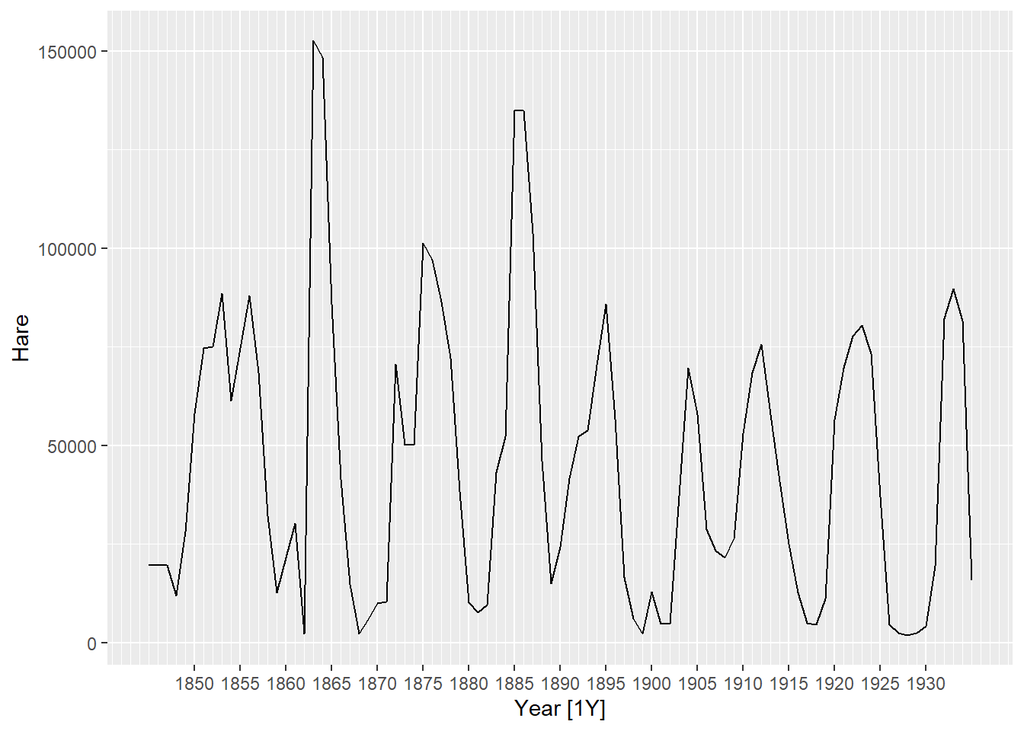

```r
#NOTE: because we are working with years, stored as double or int
# instead of as a specific date object, it is best to use sequences
# to define the ticks of the axes (if we wish to control them)

# To define their bounds we use the min() and max() function. We extend them
# a bit further because the x axis itself extends a bit further as well.
major_ticks_seq = seq(min(Hare_tr$Year)+5, max(Hare_tr$Year)-5, 5)
minor_ticks_seq = seq(min(Hare_tr$Year)-5, max(Hare_tr$Year)+5, 1)

Hare_tr %>%

  autoplot(Hare) +

  # I use scale_x_continuous because the variable "Year" is stored as a numeric type
  # instead of a date type.
  scale_x_continuous(breaks = major_ticks_seq,
                     minor_breaks = minor_ticks_seq)
```

There is a string difference between the peaks of each cycle.

In this case **there is no point in depicting the seasonal plot or the seasonal subseries plot** because **we are dealing with yearly data** and therefore **there is no seasonality analysis**. Remember that seasonal patterns are associated to calendar structures (quarters, months, weeks, days, hours…). Therefore **if we have yearly data** there is **no seasonality to be analysed**.

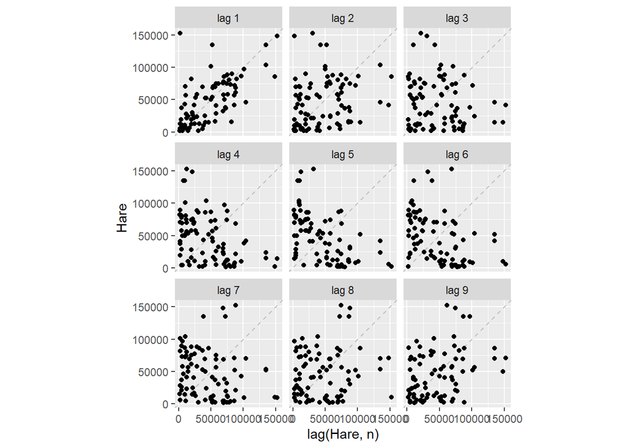

```r
Hare_tr %>%
  gg_lag(Hare, geom='point')
```

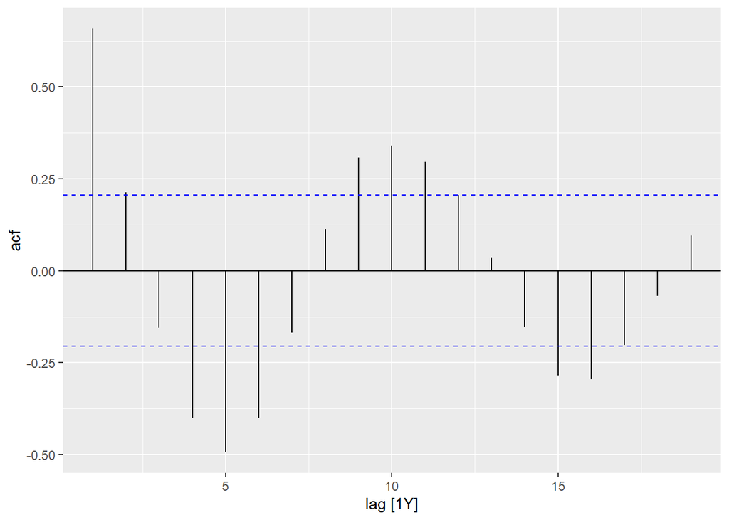

```r
Hare_tr %>%
  ACF(Hare) %>% autoplot()
```

## 2.3 H02 sales in Australia

The PBS dataset included in fpp3 contains Monthly Medicare Australia prescription data. Check `?PBS` for further info.

```r
head(PBS)
```

```
## # A tsibble: 6 x 9 [1M]
## # Key:       Concession, Type, ATC1, ATC2 [1]
##      Month Concession   Type   ATC1  ATC1_desc    ATC2  ATC2_desc  Scripts  Cost
##      <mth> <chr>        <chr>  <chr> <chr>        <chr> <chr>        <dbl> <dbl>
## 1 1991 Jul Concessional Co-pa~ A     Alimentary ~ A01   STOMATOLO~   18228 67877
## 2 1991 Aug Concessional Co-pa~ A     Alimentary ~ A01   STOMATOLO~   15327 57011
## 3 1991 Sep Concessional Co-pa~ A     Alimentary ~ A01   STOMATOLO~   14775 55020
## 4 1991 Oct Concessional Co-pa~ A     Alimentary ~ A01   STOMATOLO~   15380 57222
## 5 1991 Nov Concessional Co-pa~ A     Alimentary ~ A01   STOMATOLO~   14371 52120
## 6 1991 Dec Concessional Co-pa~ A     Alimentary ~ A01   STOMATOLO~   15028 54299
```

We would like to focus on the prescriptions with ATC (Anatomical Therapeutic Chemical Index level 2) equal to H02. This group corresponds to corticosteroids for systemic use (https://en.wikipedia.org/wiki/ATC_code_H02#:~:text=ATC%20code%20H02%20Corticosteroids%20for%20systemic%20use%20is,the%20classification%20of%20drugs%20and%20other%20medical%20products.)

The following code filters out the dataset and groups the total monthly costs associated to these drugs. **This `h02` series is the time series you should explore.**

**Explanation**: what this particular `group_by()` does.

```r
head(PBS)
```

```
## # A tsibble: 6 x 9 [1M]
## # Key:       Concession, Type, ATC1, ATC2 [1]
##      Month Concession   Type   ATC1  ATC1_desc    ATC2  ATC2_desc  Scripts  Cost
##      <mth> <chr>        <chr>  <chr> <chr>        <chr> <chr>        <dbl> <dbl>
## 1 1991 Jul Concessional Co-pa~ A     Alimentary ~ A01   STOMATOLO~   18228 67877
## 2 1991 Aug Concessional Co-pa~ A     Alimentary ~ A01   STOMATOLO~   15327 57011
## 3 1991 Sep Concessional Co-pa~ A     Alimentary ~ A01   STOMATOLO~   14775 55020
## 4 1991 Oct Concessional Co-pa~ A     Alimentary ~ A01   STOMATOLO~   15380 57222
## 5 1991 Nov Concessional Co-pa~ A     Alimentary ~ A01   STOMATOLO~   14371 52120
## 6 1991 Dec Concessional Co-pa~ A     Alimentary ~ A01   STOMATOLO~   15028 54299
```

### group_by() + n()

Examining the dataset, to filter out costs corresponding to the category `ATC2 = h02` and generate data with the monthly expenses corresponding to that grop.

When using `group_by()`, we can always combine it with `summarise()` + `n()` to check the size of each of the groups being formed:

```r
PBS %>%
  filter(ATC2 == "H02") %>%
  group_by(ATC2) %>%
  summarise(
    # Returns the size of each group
    size = n()
  )
```

```
## # A tsibble: 204 x 3 [1M]
## # Key:       ATC2 [1]
##    ATC2     Month  size
##    <chr>    <mth> <int>
##  1 H02   1991 Jul     4
##  2 H02   1991 Aug     4
##  3 H02   1991 Sep     4
##  4 H02   1991 Oct     4
##  5 H02   1991 Nov     4
##  6 H02   1991 Dec     4
##  7 H02   1992 Jan     4
##  8 H02   1992 Feb     4
##  9 H02   1992 Mar     4
## 10 H02   1992 Apr     4
## # ... with 194 more rows
```

```r
PBS %>%
  filter(ATC2 == "H02") %>%
  select(ATC2, Month, Cost, everything()) %>%
  arrange(Month)
```

```
## # A tsibble: 816 x 9 [1M]
## # Key:       Concession, Type, ATC1, ATC2 [4]
##    ATC2     Month   Cost Concession   Type   ATC1  ATC1_desc   ATC2_desc Scripts
##    <chr>    <mth>  <dbl> <chr>        <chr>  <chr> <chr>       <chr>       <dbl>
##  1 H02   1991 Jul 317384 Concessional Co-pa~ H     Systemic h~ CORTICOS~   63261
##  2 H02   1991 Jul  82929 Concessional Safet~ H     Systemic h~ CORTICOS~   12211
##  3 H02   1991 Jul  20178 General      Co-pa~ H     Systemic h~ CORTICOS~    4013
##  4 H02   1991 Jul   9304 General      Safet~ H     Systemic h~ CORTICOS~    2101
##  5 H02   1991 Aug 269891 Concessional Co-pa~ H     Systemic h~ CORTICOS~   53528
##  6 H02   1991 Aug 100602 Concessional Safet~ H     Systemic h~ CORTICOS~   14827
##  7 H02   1991 Aug  16519 General      Co-pa~ H     Systemic h~ CORTICOS~    3397
##  8 H02   1991 Aug  13894 General      Safet~ H     Systemic h~ CORTICOS~    2970
##  9 H02   1991 Sep 269703 Concessional Co-pa~ H     Systemic h~ CORTICOS~   52822
## 10 H02   1991 Sep 128900 Concessional Safet~ H     Systemic h~ CORTICOS~   18896
## # ... with 806 more rows
```

We would like to add all those costs together, and that is what the following code does:

```r
h02 <- PBS %>%

  filter(ATC2 == "H02") %>%
  group_by(ATC2, ATC2_desc) %>%
  summarise(Cost = sum(Cost))

head(h02)
```

```
## # A tsibble: 6 x 4 [1M]
## # Key:       ATC2, ATC2_desc [1]
## # Groups:    ATC2 [1]
##   ATC2  ATC2_desc                           Month   Cost
##   <chr> <chr>                               <mth>  <dbl>
## 1 H02   CORTICOSTEROIDS FOR SYSTEMIC USE 1991 Jul 429795
## 2 H02   CORTICOSTEROIDS FOR SYSTEMIC USE 1991 Aug 400906
## 3 H02   CORTICOSTEROIDS FOR SYSTEMIC USE 1991 Sep 432159
## 4 H02   CORTICOSTEROIDS FOR SYSTEMIC USE 1991 Oct 492543
## 5 H02   CORTICOSTEROIDS FOR SYSTEMIC USE 1991 Nov 502369
## 6 H02   CORTICOSTEROIDS FOR SYSTEMIC USE 1991 Dec 602652
```

### ungroup()

**Ungrouping**: note that, in the above output, there is an indication that the data is still grouped following the variable ATC2. This means that any operations being performed on the data are performed on the grouped data.

As an example, let us try to simply make a sub-selection of `Month` and `Cost` on this data:

```r
head(select(h02, Month, Cost))
```

```
## # A tsibble: 6 x 3 [1M]
## # Key:       ATC2 [1]
## # Groups:    ATC2 [1]
##   ATC2     Month   Cost
##   <chr>    <mth>  <dbl>
## 1 H02   1991 Jul 429795
## 2 H02   1991 Aug 400906
## 3 H02   1991 Sep 432159
## 4 H02   1991 Oct 492543
## 5 H02   1991 Nov 502369
## 6 H02   1991 Dec 602652
```

We observe that the variable `ATC2` has been automatically added, despite our intention to drop it in our select statement. The reason is that the data is still grouped using this variable under the hood, and therefore this variable is necessary and cannot be dropped.

If we wish to remove grouping and return to operations on ungrouped data, we need to use the function `ungroup()`

```r
h02 <- h02 %>%
  ungroup() %>%
  select(Month, Cost)

head(h02)
```

```
## # A tsibble: 6 x 2 [1M]
##      Month   Cost
##      <mth>  <dbl>
## 1 1991 Jul 429795
## 2 1991 Aug 400906
## 3 1991 Sep 432159
## 4 1991 Oct 492543
## 5 1991 Nov 502369
## 6 1991 Dec 602652
```

Now we have been able to drop the variable ATC2.

### Analysis

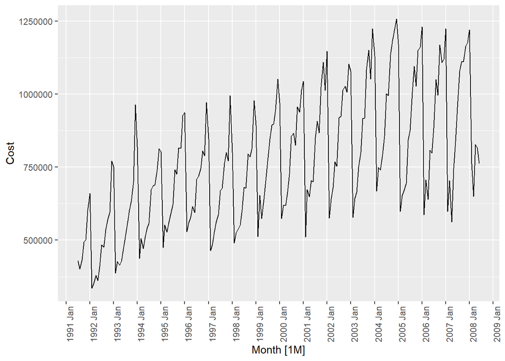

```r
h02 %>%
  autoplot(Cost) +

  # We use scale_x_yearmonth() because these are the units of the time index
  scale_x_yearmonth(date_breaks = "1 year",
                    minor_breaks = "1 year") +

  # Flip x-labels by 90 degrees
  theme(axis.text.x = element_text(angle = 90))
```

The graph revels yearly seasonality as well as an upwards trend. Further, the variability in the seasonal pattern seems to be proportional to the level of the trend.

There is as well a noteworthy drop every February.

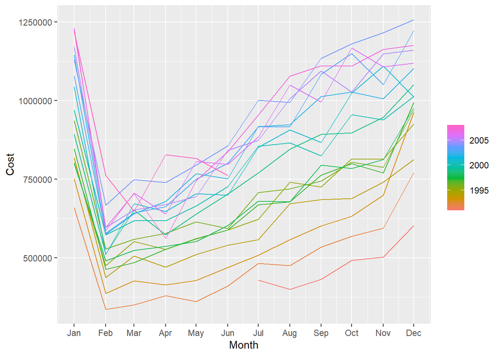

```r
h02 %>%
  gg_season(Cost)
```

The graph reveals the underlying upwards trend of the series, as well as the drop occurring every February.

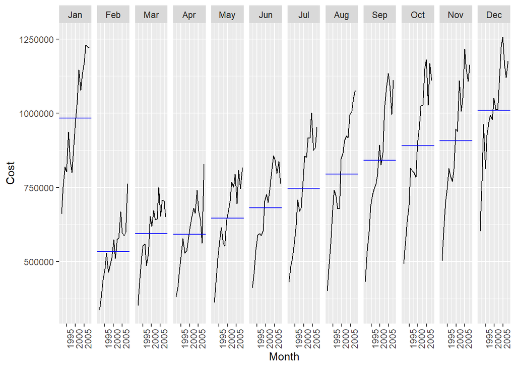

```r
h02 %>%
  gg_subseries(Cost)
```

This seasonal subseries plot reveals that months with typically higher peaks have experienced a greater growth (greater difference between their lowest and greatest record) than months with lower records.

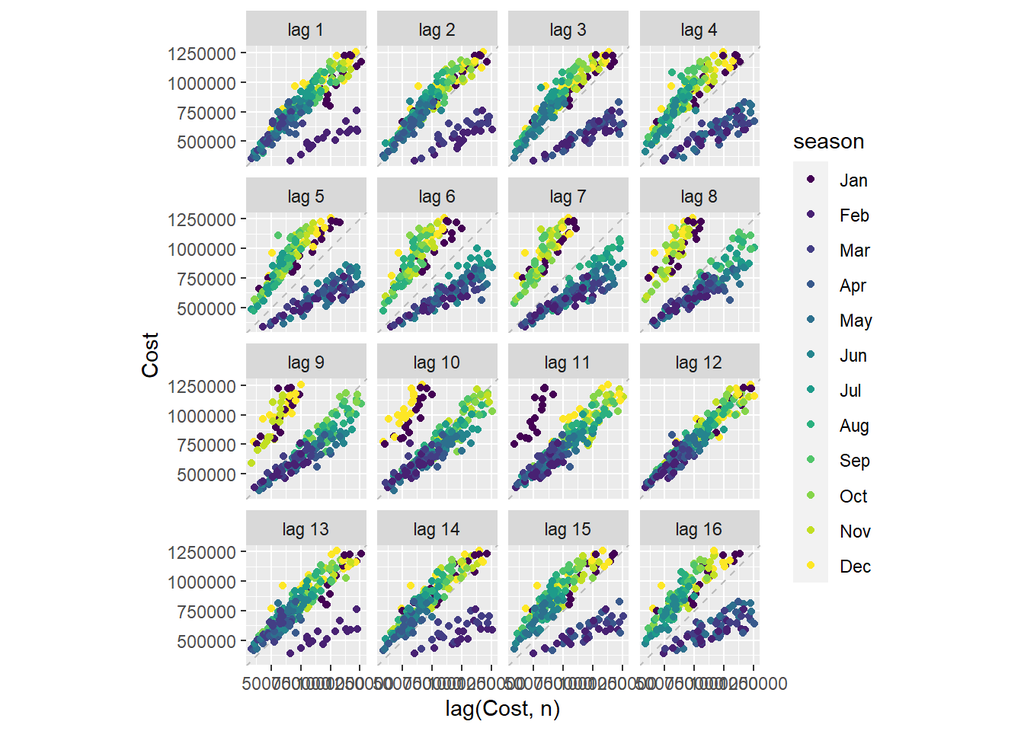

```r
h02 %>%
  gg_lag(Cost, geom='point', lags=1:16)
```

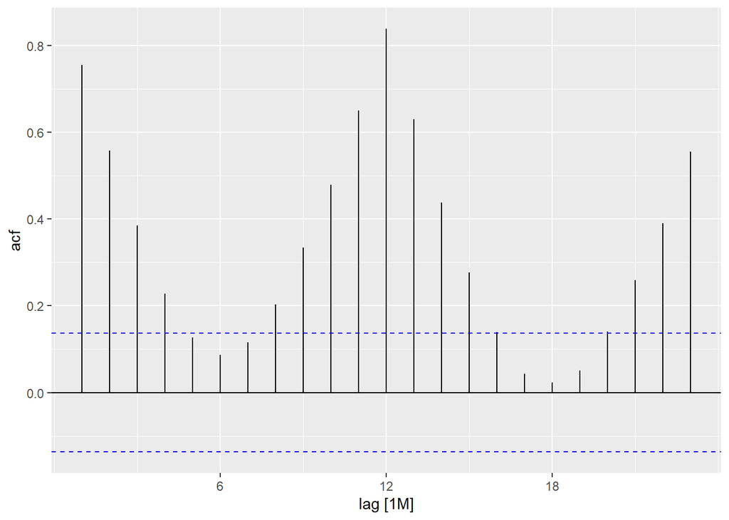

```r
h02 %>%
  ACF(Cost) %>% autoplot()
```

## 2.4 US gasoline sales

The us_gasoline dataset, loaded with fpp3, contains weely data beginning on Week 6 1991 and ending on Week 3 2017. Units are “million barrels per day”. This is the time series you need to analyse

```r
head(us_gasoline)
```

```
## # A tsibble: 6 x 2 [1W]
##       Week Barrels
##     <week>   <dbl>
## 1 1991 W06    6.62
## 2 1991 W07    6.43
## 3 1991 W08    6.58
## 4 1991 W09    7.22
## 5 1991 W10    6.88
## 6 1991 W11    6.95
```

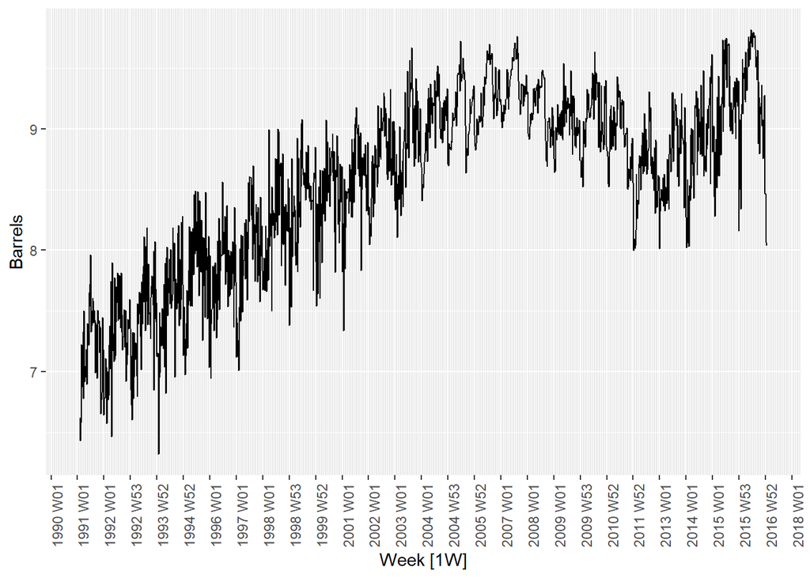

```r
us_gasoline %>%
  autoplot(Barrels) +

  # We pick scale_x_yearweek() because this is the structure of the time index
  # of the series.
  scale_x_yearweek(date_breaks = "1 year",
                   minor_breaks = "1 month") +

  # Flip x-labels by 90 degrees
  theme(axis.text.x = element_text(angle = 90))
```

- Positive trend until 2008 -> Global financial crisis.
- Production seems to take positive trend again after 2012.
- Shape of seasonality seems to have changed over time.

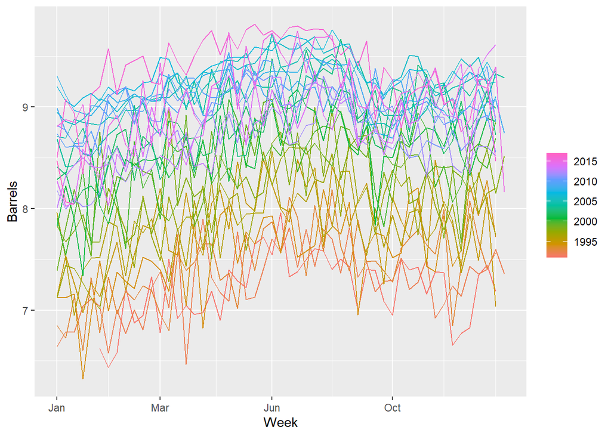

```r
us_gasoline %>%
  gg_season(Barrels)
```

The noise makes it difficult to spot the seasonal pattern.

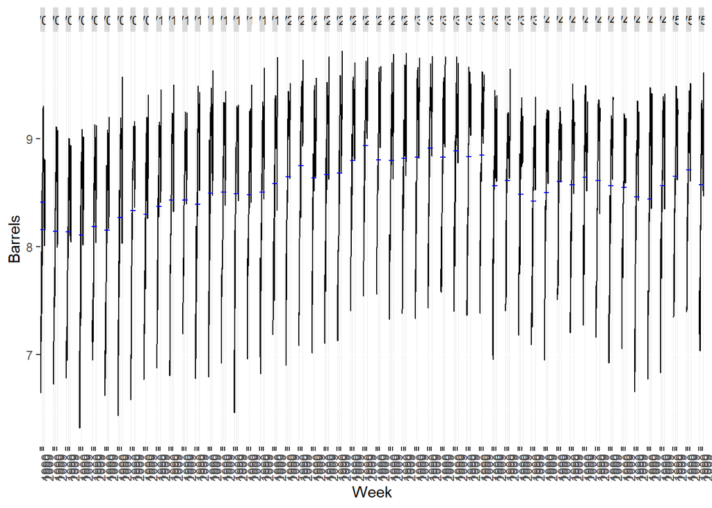

```r
us_gasoline %>%
  gg_subseries(Barrels)
```

The bluelines mark the average levels in each week of the year. On average, production seems to increase until Q3 to then decrease.

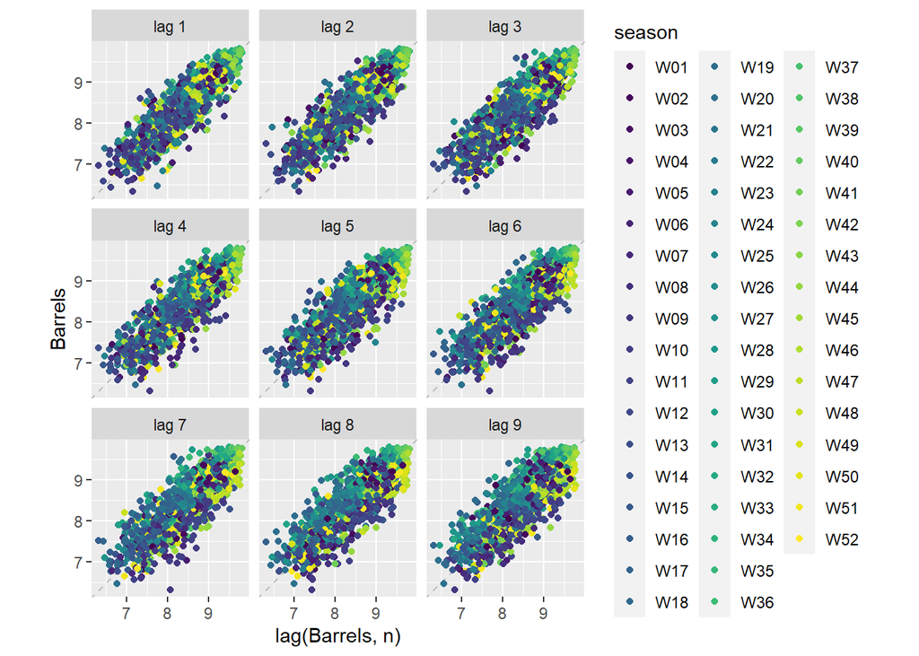

```r
us_gasoline %>%
  gg_lag(Barrels, geom='point')
```

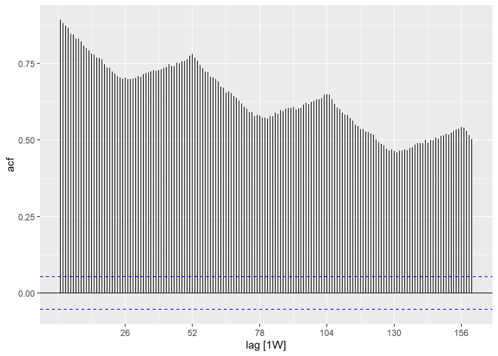

```r
us_gasoline %>%
  ACF(Barrels, lag_max = 160) %>% autoplot()
```

In this case, the lagplots are not all that useful because of the big amount of weeks per year. In order to see the seasonal pattern on the correlogram, we need to increase the number of lags at least beyond 52 (number of weeks in a year). If we do this, we clearly observe yearly seasonality.

# 3. Stock prices

The GAFA stock prices dataset in the ffp3 package contains historical stock prices from 2014-2018 for Google, Amazon, Facebook and Apple. All prices are in $USD.

## 3.1 Use `filter()` and `group_by()` to find what days corresponded to the peak closing price for each of the four stocks in `gafa_stock`

```r
gafa_stock %>%
  group_by(Symbol) %>%
  filter(Close == max(Close))
```

```
## # A tsibble: 4 x 8 [!]
## # Key:       Symbol [4]
## # Groups:    Symbol [4]
##   Symbol Date        Open  High   Low Close Adj_Close   Volume
##   <chr>  <date>     <dbl> <dbl> <dbl> <dbl>     <dbl>    <dbl>
## 1 AAPL   2018-10-03  230.  233.  230.  232.      230. 28654800
## 2 AMZN   2018-09-04 2026. 2050. 2013  2040.     2040.  5721100
## 3 FB     2018-07-25  216.  219.  214.  218.      218. 58954200
## 4 GOOG   2018-07-26 1251  1270. 1249. 1268.     1268.  2405600
```

## 3.2 Google Stock Prices

The following code computes the daily changes in Google closing stock prices for 2018:

```r
dgoog <- gafa_stock %>%

  # Filter data for google and year 2018
  filter(Symbol == "GOOG", year(Date) >= 2018) %>%

  # Creates a new index based on the trading day
  mutate(trading_day = row_number()) %>%
  select(Symbol, trading_day, Close) %>%

  # Update the tsibble changing the index to the trading day
  update_tsibble(index = trading_day, regular = TRUE) %>%

  # Compute the difference in closing price
  mutate(diff = difference(Close, lag = 1))

head(dgoog)
```

```
## # A tsibble: 6 x 5 [1]
## # Key:       Symbol [1]
##   Symbol trading_day Close Date         diff
##   <chr>        <int> <dbl> <date>      <dbl>
## 1 GOOG             1 1065  2018-01-02 NA
## 2 GOOG             2 1082. 2018-01-03 17.5
## 3 GOOG             3 1086. 2018-01-04  3.92
## 4 GOOG             4 1102. 2018-01-05 15.8
## 5 GOOG             5 1107. 2018-01-08  4.71
## 6 GOOG             6 1106. 2018-01-09 -0.680
```

1. Can you compute the column diff using the `lag()` function instead of the function difference()?. If so, do it and store it in a separate column called `diff2`. Then compute their difference to prove they are the same. Hint: you need to compute the first lag of the variable Close to do this.

```r
dgoog %>%
  mutate(diff2 = Close - lag(Close, 1)) %>%
  mutate(check = diff - diff2)
```

```
## # A tsibble: 251 x 7 [1]
## # Key:       Symbol [1]
##    Symbol trading_day Close Date         diff  diff2 check
##    <chr>        <int> <dbl> <date>      <dbl>  <dbl> <dbl>
##  1 GOOG             1 1065  2018-01-02 NA     NA        NA
##  2 GOOG             2 1082. 2018-01-03 17.5   17.5       0
##  3 GOOG             3 1086. 2018-01-04  3.92   3.92      0
##  4 GOOG             4 1102. 2018-01-05 15.8   15.8       0
##  5 GOOG             5 1107. 2018-01-08  4.71   4.71      0
##  6 GOOG             6 1106. 2018-01-09 -0.680 -0.680     0
##  7 GOOG             7 1103. 2018-01-10 -3.65  -3.65      0
##  8 GOOG             8 1106. 2018-01-11  2.91   2.91      0
##  9 GOOG             9 1122. 2018-01-12 16.7   16.7       0
## 10 GOOG            10 1122. 2018-01-16 -0.5   -0.5       0
## # ... with 241 more rows
```

**QUESTION**: Why is `NA - NA` = `NA`? Can you give a mathematical example?

2. Why was it necessary to create a new index for the tsibble based on the trading day? Hint: run `?update_tsibble` on the console to access the documentation and read about the argument `regular`.

3. Create a time plot of the closing prices and a time plot of the differences.

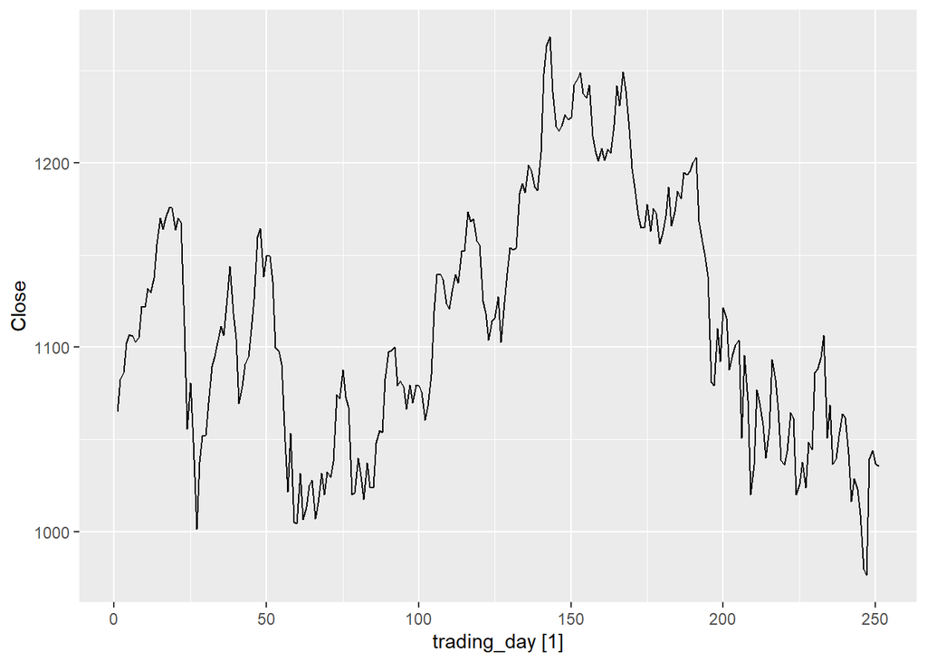

```r
dgoog %>% autoplot(Close)
```

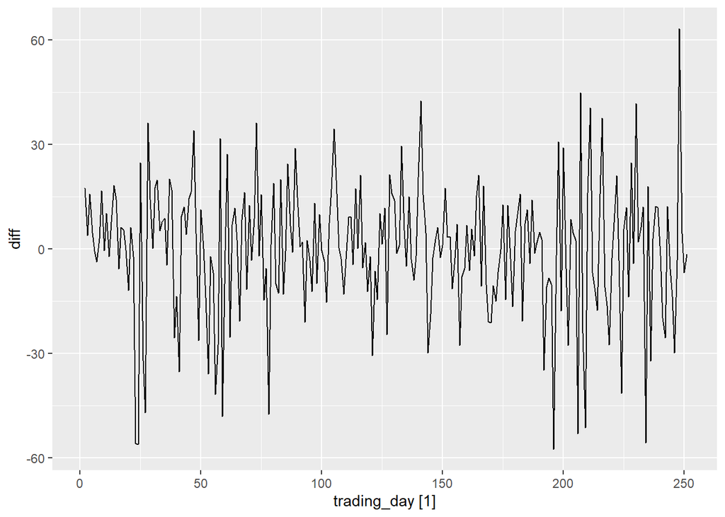

```r
dgoog %>% autoplot(diff)
```

4. Create the correlogram of the Closing prices and of the differences in prices using the `ACF()` and `autoplot()` functions. Depict 100 lags (look at the argument `lag_max`).

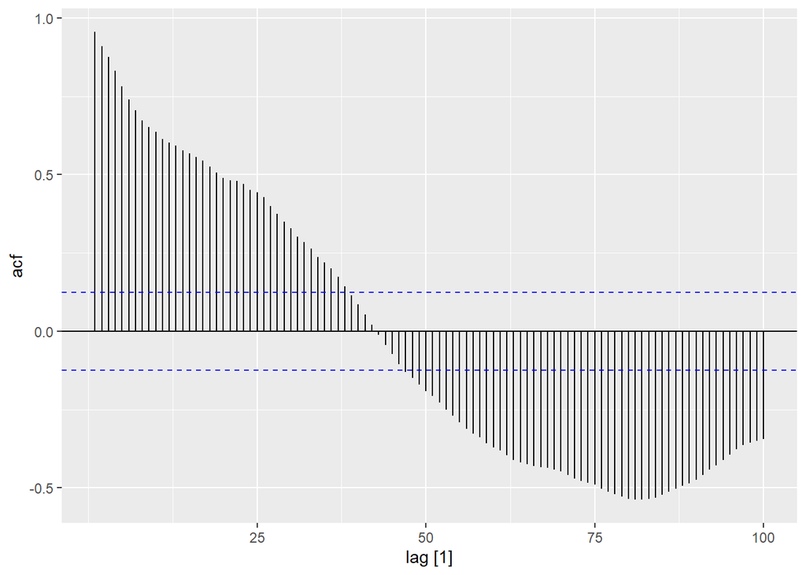

```r
dgoog %>% ACF(Close, lag_max=100) %>% autoplot()
```

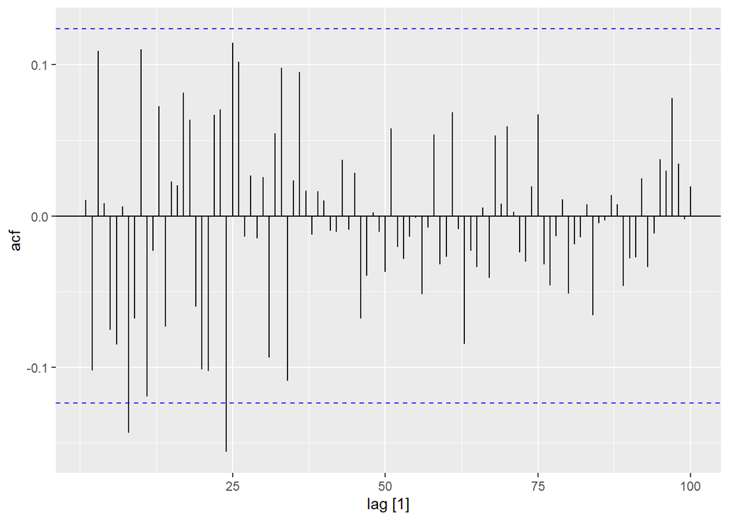

```r
dgoog %>% ACF(diff, lag_max=100) %>% autoplot()
```

- Do the differences in the stock prices look like white noise?

More than 95% of the values of the correlogram are within the dashed bounds, so we can consider the differences in the stock prices as white nose

- What about the original closing prices?

Not so much for the closing prices.

# 4. OPTIONAL: if you finish these assignments and feel like you want more, we can use Yahoo Finance API to download historical data of the SP500 index and perform some analysis on it.